# Bike Demand - Regression Analysis

vincentole

# Predicting Bike Sharing Demand

The data is taken from the [Kaggle Challenge - Bike Sharing Demand](https://www.kaggle.com/c/bike-sharing-demand/data).

The goal is to predict daily demand on bike share rentals (**count**) using the data set with the following columns:

- **datetime** - hourly date + timestamp
- **season** - 1 = spring, 2 = summer, 3 = fall, 4 = winter
- **holiday** - whether the day is considered a holiday
- **workingday** - whether the day is neither a weekend nor holiday
- **weather** - 1: Clear, Few clouds, Partly cloudy, Partly cloudy; 2: Mist + Cloudy, Mist + Broken clouds, Mist + Few clouds, Mist; 3: Light Snow, Light Rain + Thunderstorm + Scattered clouds, Light Rain + Scattered clouds; 4: Heavy Rain + Ice Pallets + Thunderstorm + Mist, Snow + Fog
- **temp** - temperature in Celsius
- **atemp** - “feels like” temperature in Celsius
- **humidity** - relative humidity
- **windspeed** - wind speed

The number of riders (**count**) is split between casual and registered. We will concentrate on `count`.

- **casual** - number of non-registered user rentals initiated
- **registered** - number of registered user rentals initiated
- **count** - number of total rentals

## Load the Data

First we load the data:

```r
# Load packages
library(lubridate)
library(GGally)
library(tidyverse)

# Load train data (train.csv)
data <- read_csv("train.csv")

# Load test data (test.csv)
test <- read_csv("test.csv")

# Load the file "sampleSubmission.csv" to check submission format.
submission <- read_csv("sampleSubmission.csv")
```

Next we check the file structure.

Files structure of `data`:

```r
glimpse(data)
```

```
## Rows: 10,886
## Columns: 12
## $ datetime   <dttm> 2011-01-01 00:00:00, 2011-01-01 01:00:00, 2011-01-01 02:00~
## $ season     <dbl> 1, 1, 1, 1, 1, 1, 1, 1, 1, 1, 1, 1, 1, 1, 1, 1, 1, 1, 1, 1,~
## $ holiday    <dbl> 0, 0, 0, 0, 0, 0, 0, 0, 0, 0, 0, 0, 0, 0, 0, 0, 0, 0, 0, 0,~
## $ workingday <dbl> 0, 0, 0, 0, 0, 0, 0, 0, 0, 0, 0, 0, 0, 0, 0, 0, 0, 0, 0, 0,~
## $ weather    <dbl> 1, 1, 1, 1, 1, 2, 1, 1, 1, 1, 1, 1, 1, 2, 2, 2, 2, 2, 3, 3,~
## $ temp       <dbl> 9.84, 9.02, 9.02, 9.84, 9.84, 9.84, 9.02, 8.20, 9.84, 13.12~
## $ atemp      <dbl> 14.395, 13.635, 13.635, 14.395, 14.395, 12.880, 13.635, 12.~
## $ humidity   <dbl> 81, 80, 80, 75, 75, 75, 80, 86, 75, 76, 76, 81, 77, 72, 72,~
## $ windspeed  <dbl> 0.0000, 0.0000, 0.0000, 0.0000, 0.0000, 6.0032, 0.0000, 0.0~
## $ casual     <dbl> 3, 8, 5, 3, 0, 0, 2, 1, 1, 8, 12, 26, 29, 47, 35, 40, 41, 1~
## $ registered <dbl> 13, 32, 27, 10, 1, 1, 0, 2, 7, 6, 24, 30, 55, 47, 71, 70, 5~
## $ count      <dbl> 16, 40, 32, 13, 1, 1, 2, 3, 8, 14, 36, 56, 84, 94, 106, 110~
```

File structure of `test`:

```r
glimpse(test)
```

```
## Rows: 6,493
## Columns: 9
## $ datetime   <dttm> 2011-01-20 00:00:00, 2011-01-20 01:00:00, 2011-01-20 02:00~
## $ season     <dbl> 1, 1, 1, 1, 1, 1, 1, 1, 1, 1, 1, 1, 1, 1, 1, 1, 1, 1, 1, 1,~
## $ holiday    <dbl> 0, 0, 0, 0, 0, 0, 0, 0, 0, 0, 0, 0, 0, 0, 0, 0, 0, 0, 0, 0,~
## $ workingday <dbl> 1, 1, 1, 1, 1, 1, 1, 1, 1, 1, 1, 1, 1, 1, 1, 1, 1, 1, 1, 1,~
## $ weather    <dbl> 1, 1, 1, 1, 1, 1, 1, 1, 1, 2, 1, 2, 2, 2, 2, 2, 2, 2, 2, 1,~
## $ temp       <dbl> 10.66, 10.66, 10.66, 10.66, 10.66, 9.84, 9.02, 9.02, 9.02, ~
## $ atemp      <dbl> 11.365, 13.635, 13.635, 12.880, 12.880, 11.365, 10.605, 10.~
## $ humidity   <dbl> 56, 56, 56, 56, 56, 60, 60, 55, 55, 52, 48, 45, 42, 45, 45,~
## $ windspeed  <dbl> 26.0027, 0.0000, 0.0000, 11.0014, 11.0014, 15.0013, 15.0013~
```

File structure of `submission`:

```r
glimpse(submission)
```

```
## Rows: 6,493
## Columns: 2
## $ datetime <dttm> 2011-01-20 00:00:00, 2011-01-20 01:00:00, 2011-01-20 02:00:0~
## $ count    <dbl> 11, 5, 3, 2, 2, 8, 35, 99, 163, 78, 44, 48, 65, 59, 53, 58, 8~
```

Further, we check if all columns are the the same for the train and test data:

```r
# Remove additional features from train data
data <- data %>% select(-casual,-registered)
# Confirm that variables are identical
cat("Train: ", names(data), "\n", "Test: ", names(test))
```

```
## Train:  datetime season holiday workingday weather temp atemp humidity windspeed count
##  Test:  datetime season holiday workingday weather temp atemp humidity windspeed
```

```r
# Attatch data
attach(data)
```

**Classification vs. Regression**

What is the difference between a regression problem and a classification problem?

**Answer:** Regression problems fit a model with the objective of estimating a quantitative (continuous or discrete) outcome variable. Classification problems fit a model with the objective of estimating a categorical outcome variable. Graphically this means that classification tries to separate the data into groups, while regression tries to fit a model close to the data. Since we try to predict the bike demand (count), which is a discrete variable, the problem at hand is a regression problem.

## Data Preparation

Next we will do some feature engineering and data preparation.

```r
# Function to extract the year from datetime
year_get <- function(dtetime) {
  year <- as.integer(map(strsplit( as.character(dtetime), "-"), 1))
  return(year)
}


# Extract year from the datetime
data$year <- sapply(data$datetime, year_get)
test$year <- sapply(test$datetime, year_get)
```

```r
# Extract "month", "hour" (0-23), and "weekday" (1-7) from datetime
data <- data %>% mutate(month = as.integer( month(datetime) ),
                        hour = as.integer( hour(datetime) ),
                        weekday = as.integer( wday(datetime,
                          week_start = getOption("lubridate.week.start", 1)) ))

test <- test %>% mutate(month = as.integer( month(datetime) ),
                        hour = as.integer( hour(datetime) ),
                        weekday = as.integer( wday(datetime,
                          week_start = getOption("lubridate.week.start", 1)) ))




# Make sure that "datetime" is of the type "POSIXct" "POSIXt" in both
# "data" and "test" data frames.
class(data$datetime)
```

```
## [1] "POSIXct" "POSIXt"
```

```r
class(test$datetime)
```

```
## [1] "POSIXct" "POSIXt"
```

Next we make sure that the following categorical variables are of the type “factor”:

- season
- holiday
- workingday
- weather
- year
- month
- hour
- weekday

```r
# Create a vector with the names of categorical variables we want
# to transform to factor.
categorical <- c("season", "holiday", "workingday",
                 "weather", "year", "month", "hour", "weekday")

# Transform categorical variables into factors
data[categorical] <- lapply(data[categorical], factor)
test[categorical] <- lapply(test[categorical], factor)
```

## Exploring the Data

Now we will concentrate on the train part of the data which we have stored as a “data” data frame. To get a better grasp of the problem, we will start from visualizing the dependent variable “count”.

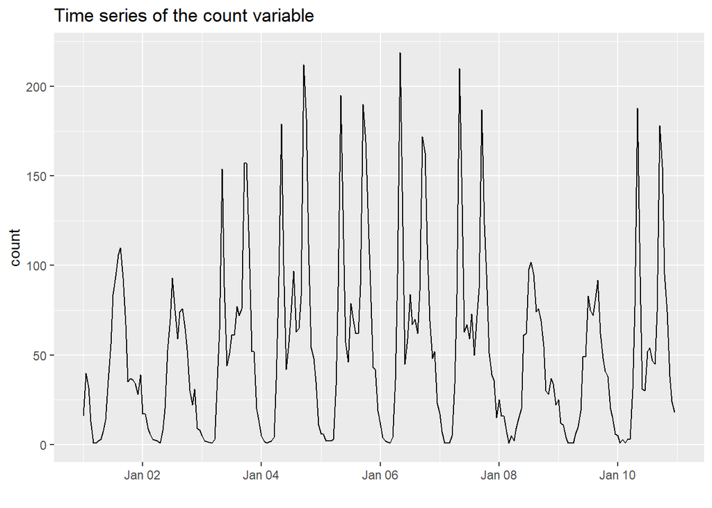

```r
# First we inspect the dependent variable
plot_data <- data %>% filter(datetime < as.Date(datetime[1]) + 10)
ggplot(plot_data, aes(x = datetime, y = count)) +
  geom_line() +
  labs(title = "Time series of the count variable", x = "")
```

**Plot Interpretation**

What do we learn from this plot?

**Answer:** We can clearly identify a cyclical pattern. The first pattern is between weekdays and weekends, whereas on weekends the total count of bike rentals seems to be lower than on weekdays. The second pattern can be observed during each day. During the night there are almost no rentals. We can see a first peak in the morning, after which the level returns to an intermediate level. In the evening there is a second peak, after which the level falls towards zero rentals for the night. This daily distribution changes on the weekend, where there is only one peak during the middle of the day.

A first interpretation would be, that the bike rentals seem to follow the working day rush hour cycle during the week, while there is an average level of rentals throughout the day. On weekends, people sleep longer and use the bike throughout the day for trips etc.

Now, say we want to understand how the total number of bike rentals depends on the weather type. One way to gain some insight about this dependence is to use conditioned box plots.

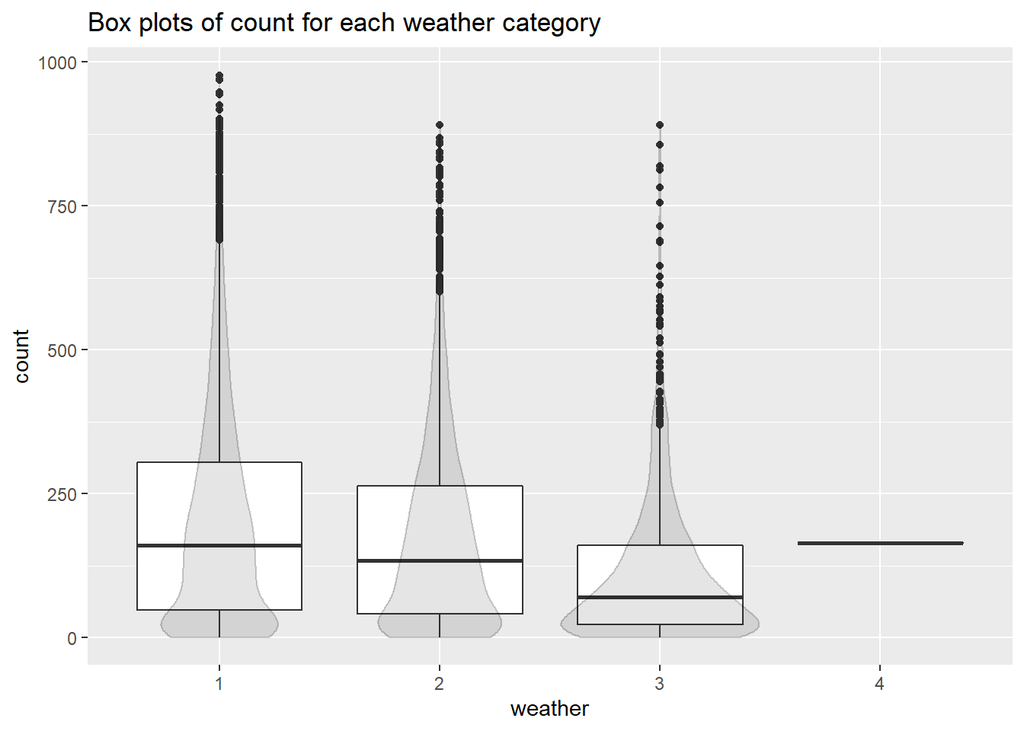

```r
# Obtain a set of box plots for the variable "count", for each value
# of the variable "weather".
# To add more information on the distribution, a violin plot is added as well.
ggplot(data, aes(x = weather, y = count)) +
  geom_boxplot() +
  geom_violin(alpha = 0.1, fill = "black", color = "#00000033") +
  labs(title = "Box plots of count for each weather category")
```

**Box Plot Interpretation**

What do we learn from these box plots?

**Answer:** The box plots show that weather seems to have an effect on the bike rents per hour. Most notably, during extremely bad weather, on first glance, there appear only very few bike rentals (164, see below), however, from the table below we can see that there is only one observation. Thus we cannot draw conclusions for very bad weather (`4`). Still, There seems to be a clear aversion of (light) rain, indicated by the lower 75% quantile and media of `3` compared to `1` and `2`. From the violin plot we can also see a clear difference between the distributions. For rainy weather (`3`), the bulk of hours shows low bike rentals and only few hours show some higher rentals. This indicates that the peak hours might be distributed differently. We will have a look at this below. The distributions between sunny and cloudy weather (`1` vs `2`) does not appear so clear cut. Still, the peak hours seem to be higher during sunny weather. This is indicated by the higher 75% quantile and whisker, while the distributions look similar. From the table below we can see that the total bike rents (`sum_count`) during sunny hours is roughly 3 times higher than during cloudy hours, while the occurrence of sunny hours (`sample_n`) is only roughly 2.5 times higher than cloudy hours. Combined with the knowledge from the box plots this indicates that the higher peek count between `1` and `2` might not play a crucial role for total rental count. In addition, we can see that the 25% quantile does not change much, while the 75% quantile increases for better weather. This indicates that the count dispersion also increases with the total count number, which might make it more difficult to predict high count hours.

Table and plot of values grouped by `weather`:

```r
# Total bike rentals per hour, grouped by weather
data %>% group_by(weather) %>% summarise(sum_count = sum(count), sample_n = n())
```

| weather | sum_count | sample_n |
| --- | --- | --- |
| 1 | 1476063 | 7192 |
| 2 | 507160 | 2834 |
| 3 | 102089 | 859 |
| 4 | 164 | 1 |

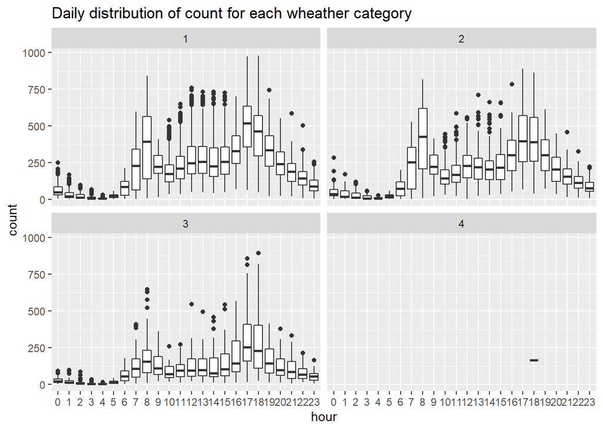

```r
# Total bike rentals per hour vs hour, grouped by weather
ggplot(data, aes(x = hour, y = count)) +
  geom_boxplot() +
  facet_wrap(weather) +
  labs(title = "Daily distribution of count for each wheather category")
```

As supposed above, the plot confirms that the daily distributions for good weather (`1` and `2`) are very similar, with the distribution of good weather being shifted upwards slightly. However, the daily distribution during rainy weather (`3`) has a considerably lower first peak and generally lower dispersion during most hours of the day. One reason could be that some people are dependent on the bike rental service and have to use it, no matter if it is raining.

To get a better understanding of the dataset, we use the `ggpairs()` function to generate a plot matrix of the data. This allows us to quickly identify strong relationships and might raise red flags to watch out for, such as colinearities.

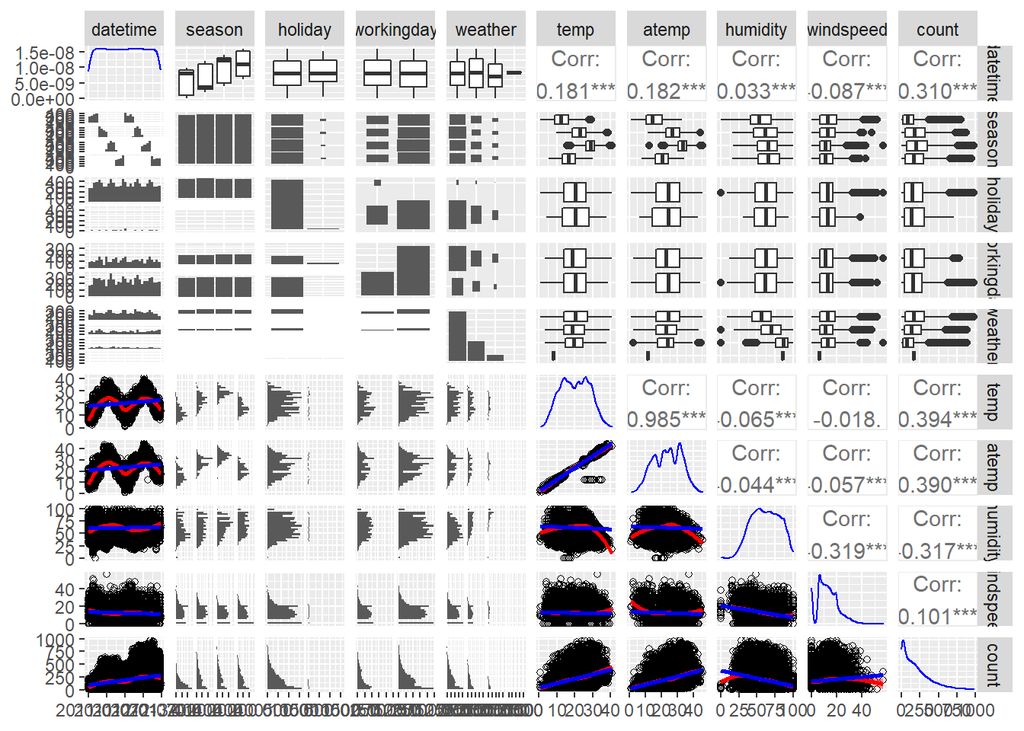

```r
# Function to add lm and loess estimation to the graphs
my_fn <- function(data, mapping, ...){
  p <- ggplot(data = data, mapping = mapping) +
    geom_point(shape = 1) +
    geom_smooth(method=loess, fill="red", color="red", ...) +
    geom_smooth(method=lm, fill="blue", color="blue", ...)
  p
}

# Select plotting data, data has to be split because the plot would not be
#   readable

# The split is made between the date variables, because there won't be
#   unexpected relationships between the date variables.
plot_data <- data %>% select(datetime:count)

# Plot pairs
ggpairs(plot_data, cardinality_threshold = NULL, progress = FALSE,
        lower = list(continuous = my_fn),
        diag = list(continuous = wrap("densityDiag",  color = "blue") ))
```

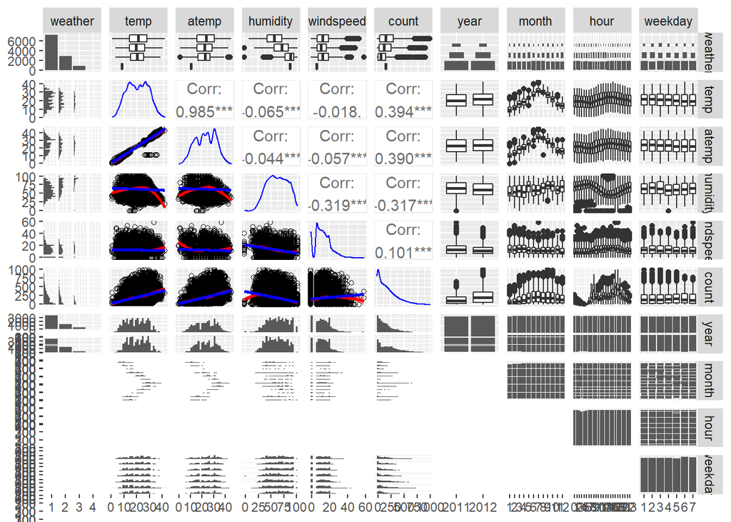

```r
# Select plotting data

plot_data <- data %>% select(weather:weekday)
# Plot pairs
ggpairs(plot_data, cardinality_threshold = NULL, progress = FALSE,
        lower = list(continuous = my_fn),
        diag = list(continuous = wrap("densityDiag",  color = "blue") ))
```

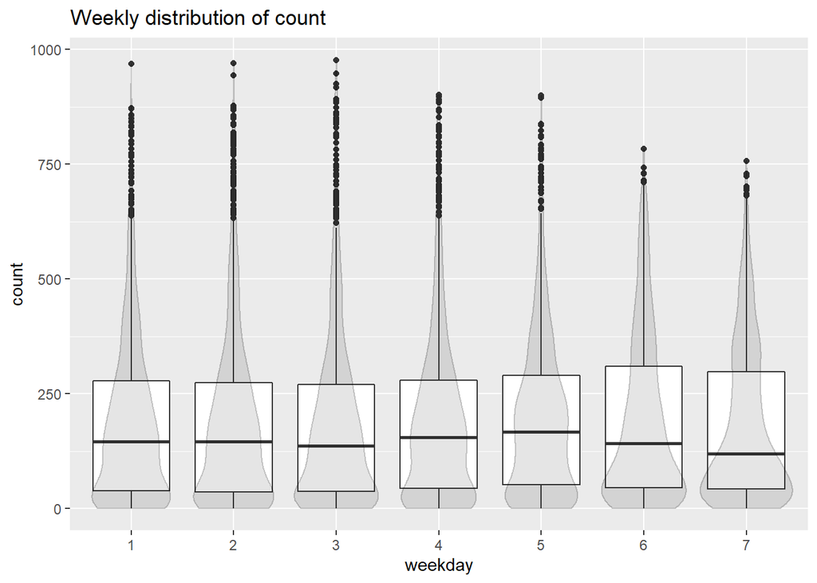

```r
# Plot weeky distribution of count
ggplot(data, aes(x = weekday, y = count)) +
  geom_boxplot() +
  geom_violin(alpha = 0.1, fill = "black", color = "#00000033") +
  labs(title = "Weekly distribution of count")
```

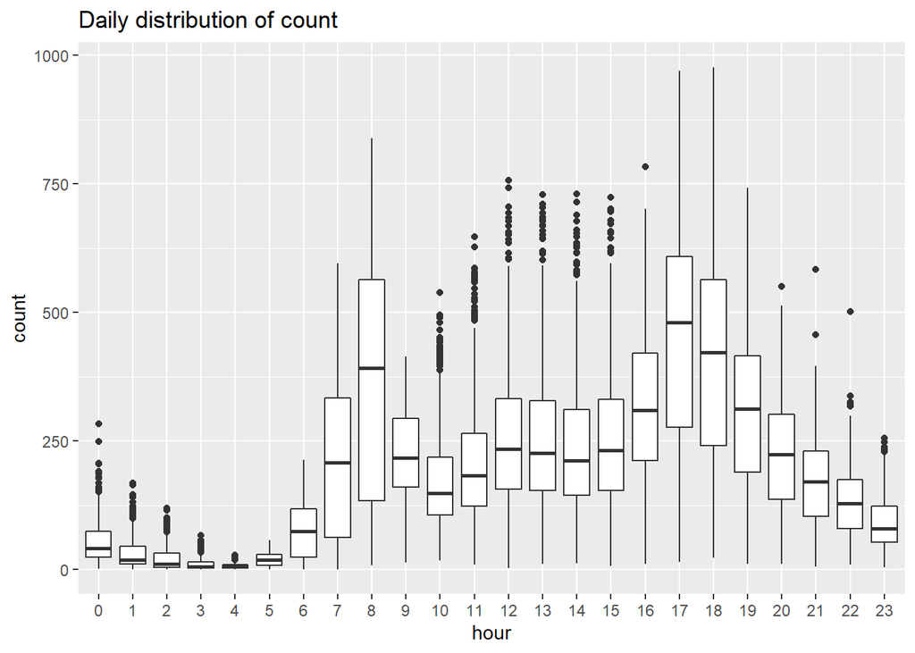

```r
# Plot daily distribution of count
ggplot(data, aes(x = hour, y = count)) +
  geom_boxplot() +
  labs(title = "Daily distribution of count")
```

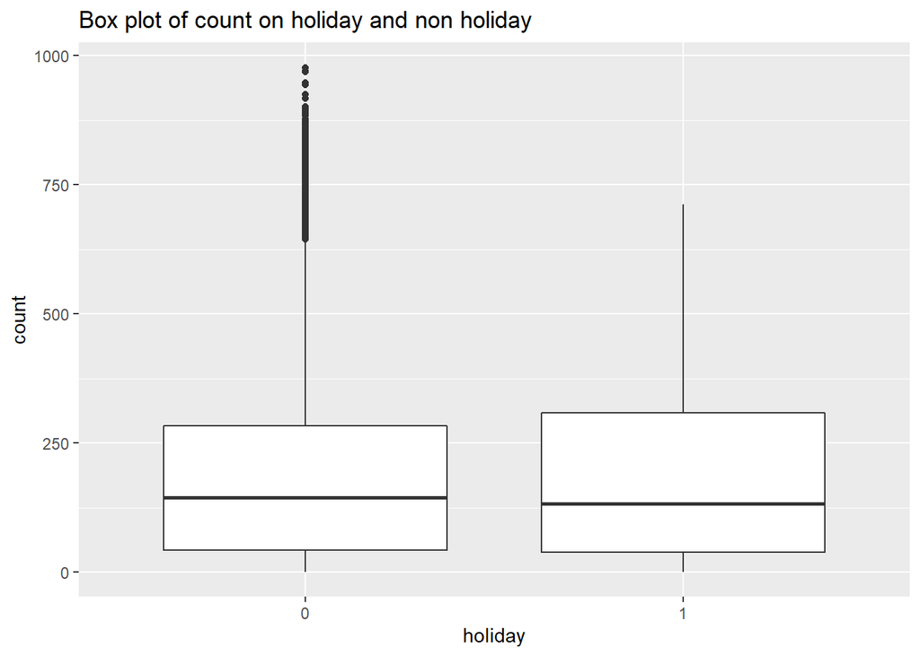

```r
# Plot box plot of count on holiday and non holiday
ggplot(data, aes(x = holiday, y = count)) +
  geom_boxplot() +
  labs(title = "Box plot of count on holiday and non holiday")
```

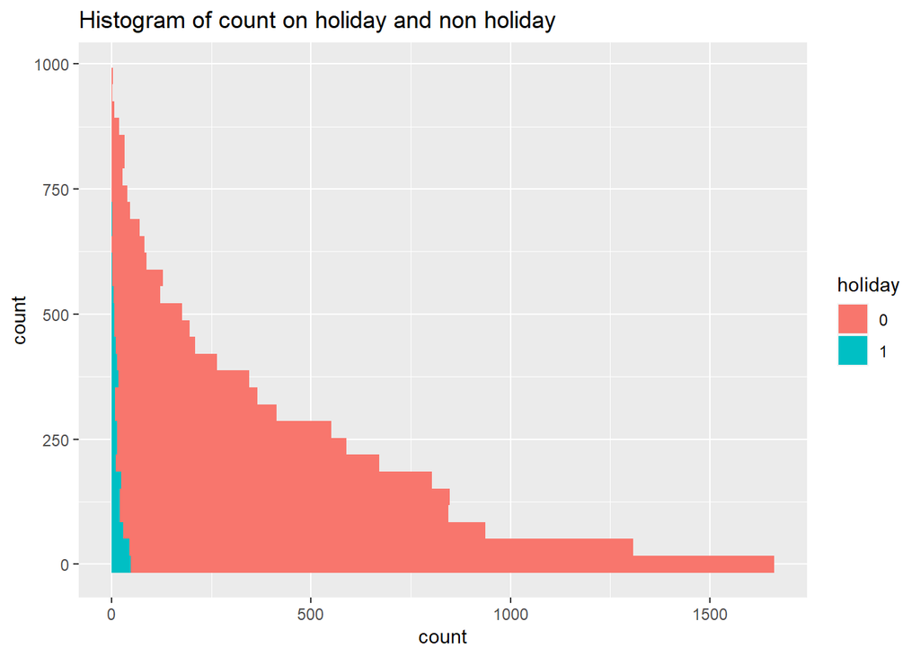

```r
# Plot histogram of count on holiday and non holiday
ggplot(data, aes(y = count, fill = holiday)) +
  geom_histogram() +
  labs(title = "Histogram of count on holiday and non holiday")
```

### Interpretation:

Looking primarily at the `count` column, we can see that there is a clear relationship of rising bike rentals from year 2011 towards year 2012, which may make predictions into 2013 more difficult, because with the limited data we don’t know if this is a long lasting trend. For our predictions within 2011 and 2012 this is not a big problem though. We can also see a clear increase of rentals during the summer in variables `datetime`, `seasons`, `year`, and `month`. Further, we have already discussed the distributions for `hour` and `weekday`.

Unexpectedly, the peak counts on `holiday` seem to be lower than on normal days and the distribution seems to be more equally spread. Higher peek counts can also be seen in the `workingday` column. Examining the daily distribution (see below) confirms this and in addition shows that the daily distribution for those days is very different. On ‘non working days’ and holidays people appear to use the bike throughout the day and not only during the morning and evening to get to work.

For the quantitative variables `temp`, `humidity`, etc. we can see some correlations which might be useful in our model. The wind speed correlation, however, is unexpectedly positive, while there still is a clear cut-off at high wind speeds. This could be subject to further inspection. Further, we can see a very high correlation and tight linear relationship between `temp` and `atemp`. This might cause problems of colinearity and should be considered when estimating the models.

Further, we can clearly identify some relationships between the independent variables. Therefore, it might be beneficial to consider some interaction terms in the modeling process.

Finally, we can see that `count` is heavily positively skewed. Thus, a `log()` transformation might improve prediction results a lot.

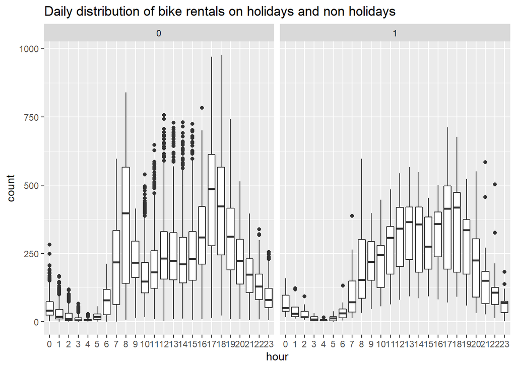

```r
# Plot the daily distribution for holiday and working day vs 'other' days
ggplot(data, aes(x = hour, y = count)) +
  geom_boxplot() +
  facet_wrap(holiday) +
  labs(title = "Daily distribution of bike rentals on holidays and non holidays")
```

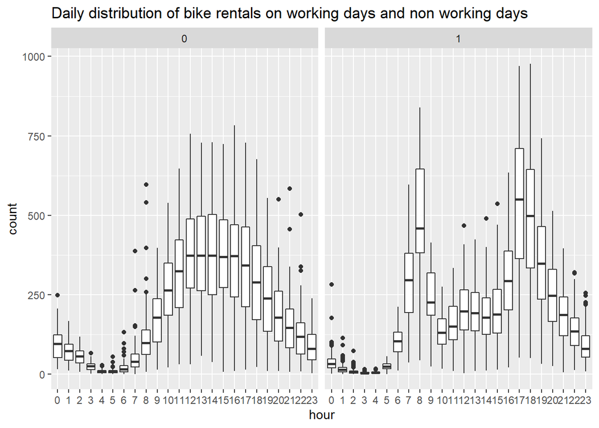

```r
ggplot(data, aes(x = hour, y = count)) +
  geom_boxplot() +
  facet_wrap(workingday) +
  labs(title = "Daily distribution of bike rentals on working days and non working days")
```

## Linear regression

The main goal is to obtain predictions for the number of bike rentals. For now, we will use a multiple linear regression to perform this task.

Therefore we split the data into training (“data_train”) and testing (“data_test”) subsets. We assign the first 60% of the consecutive data points to the “data_train” and the rest to the “data_test”. We do not shuffle the data.

```r
# Find the 60% cut off value
n <- dim(data)[1]
n_train <- as.integer(0.6*n)

# Split the data into train and test
data_train <- data[1 : n_train, ]
data_test <- data[ n_train + 1 : n, ]
```

**Training and Testing**

What is the benefit of splitting a data set into some ratio of training and testing data points?

**Answer:** Splitting the data set enables us to use the training part for model estimation, while using the testing part for model selection (prediction evaluation). This ensures independence between our estimated coefficients $\hat{\beta}$ and the independent variables $X$ for testing. Effectively it simulates out of sample prediction which, for example, lowers the chance of overfitting. Overfitting on the test set will then, hopefully, be apparent from a large estimation error in the out of sample prediction. Thus, splitting the data helps to correctly evaluate the model prediction and, thus, improves the model selection process.

First we use the train part (“data_train”) of the data to estimate multiple linear regression with the following features:

- month
- holiday
- weather
- temp
- humidity
- windspeed
- year
- hour

```r
# Fit model 1
fit1 <- lm(data = data_train, formula = count ~ month + holiday + weather +
             temp + humidity + windspeed + year + hour)
summary(fit1)
```

```
##
## Call:
## lm(formula = count ~ month + holiday + weather + temp + humidity +
##     windspeed + year + hour, data = data_train)
##
## Residuals:
##      Min       1Q   Median       3Q      Max
## -266.982  -43.186   -6.684   38.994  310.069
##
## Coefficients:
##              Estimate Std. Error t value Pr(>|t|)
## (Intercept)  -41.3790     7.2833  -5.681 1.39e-08 ***
## month2        14.2487     3.6008   3.957 7.67e-05 ***
## month3        20.5654     4.1775   4.923 8.74e-07 ***
## month4        37.4149     5.2621   7.110 1.28e-12 ***
## month5        85.2028     5.9142  14.407  < 2e-16 ***
## month6        66.9654     7.1459   9.371  < 2e-16 ***
## month7        66.7028     7.5594   8.824  < 2e-16 ***
## month8        50.9850     7.4826   6.814 1.04e-11 ***
## month9        72.7831     6.6227  10.990  < 2e-16 ***
## month10       88.4928     5.8214  15.201  < 2e-16 ***
## month11       81.4983     5.0568  16.116  < 2e-16 ***
## month12       74.2588     4.7896  15.504  < 2e-16 ***
## holiday1      -6.0614     5.5812  -1.086  0.27750
## weather2      -7.2984     2.3239  -3.141  0.00169 **
## weather3     -55.2425     3.6979 -14.939  < 2e-16 ***
## weather4    -114.1569    74.7081  -1.528  0.12655
## temp           4.1976     0.2815  14.910  < 2e-16 ***
## humidity      -0.5530     0.0650  -8.508  < 2e-16 ***
## windspeed     -0.5247     0.1186  -4.424 9.83e-06 ***
## year2012      72.8366     3.1220  23.330  < 2e-16 ***
## hour1        -12.2744     6.3687  -1.927  0.05399 .
## hour2        -19.8303     6.4004  -3.098  0.00195 **
## hour3        -30.4132     6.4949  -4.683 2.89e-06 ***
## hour4        -31.0767     6.4498  -4.818 1.48e-06 ***
## hour5        -18.7336     6.3958  -2.929  0.00341 **
## hour6         25.7954     6.3789   4.044 5.32e-05 ***
## hour7        126.1989     6.3723  19.804  < 2e-16 ***
## hour8        240.9000     6.3669  37.836  < 2e-16 ***
## hour9        126.9131     6.3778  19.899  < 2e-16 ***
## hour10        82.4594     6.3997  12.885  < 2e-16 ***
## hour11       100.7796     6.4352  15.661  < 2e-16 ***
## hour12       132.2677     6.4756  20.426  < 2e-16 ***
## hour13       129.4399     6.5284  19.827  < 2e-16 ***
## hour14       117.6200     6.5640  17.919  < 2e-16 ***
## hour15       122.7943     6.5755  18.674  < 2e-16 ***
## hour16       171.2927     6.5600  26.112  < 2e-16 ***
## hour17       291.0832     6.5287  44.585  < 2e-16 ***
## hour18       262.9889     6.4947  40.493  < 2e-16 ***
## hour19       179.8036     6.4285  27.970  < 2e-16 ***
## hour20       119.9186     6.3976  18.744  < 2e-16 ***
## hour21        83.4254     6.3780  13.080  < 2e-16 ***
## hour22        55.9523     6.3685   8.786  < 2e-16 ***
## hour23        24.8612     6.3638   3.907 9.45e-05 ***
## ---
## Signif. codes:  0 '***' 0.001 '**' 0.01 '*' 0.05 '.' 0.1 ' ' 1
##
## Residual standard error: 74.46 on 6488 degrees of freedom
## Multiple R-squared:  0.6881, Adjusted R-squared:  0.6861
## F-statistic: 340.8 on 42 and 6488 DF,  p-value: < 2.2e-16
```

Second, we use the train part (“data_train”) of the data to estimate multiple linear regression with a smaller set of features:

- month
- year
- hour

```r
# Fit model 2
fit2 <- lm(data = data_train, formula = count ~ month + year + hour)
summary(fit2)
```

```
##
## Call:
## lm(formula = count ~ month + year + hour, data = data_train)
##
## Residuals:
##     Min      1Q  Median      3Q     Max
## -304.62  -43.34   -5.19   39.46  346.83
##
## Coefficients:
##             Estimate Std. Error t value Pr(>|t|)
## (Intercept)  -53.732      5.605  -9.586  < 2e-16 ***
## month2        21.763      3.723   5.845 5.31e-09 ***
## month3        40.413      4.122   9.804  < 2e-16 ***
## month4        63.670      4.835  13.169  < 2e-16 ***
## month5       127.754      4.832  26.440  < 2e-16 ***
## month6       149.822      4.832  31.007  < 2e-16 ***
## month7       156.559      4.832  32.401  < 2e-16 ***
## month8       135.612      4.832  28.066  < 2e-16 ***
## month9       126.732      4.841  26.179  < 2e-16 ***
## month10      127.417      4.835  26.354  < 2e-16 ***
## month11      108.403      4.832  22.435  < 2e-16 ***
## month12       87.118      4.832  18.030  < 2e-16 ***
## year2012      78.240      3.253  24.050  < 2e-16 ***
## hour1        -15.747      6.725  -2.342 0.019233 *
## hour2        -24.021      6.757  -3.555 0.000380 ***
## hour3        -36.492      6.851  -5.327 1.03e-07 ***
## hour4        -40.352      6.796  -5.938 3.04e-09 ***
## hour5        -28.229      6.738  -4.190 2.83e-05 ***
## hour6         15.832      6.719   2.356 0.018485 *
## hour7        117.690      6.719  17.516  < 2e-16 ***
## hour8        235.077      6.719  34.987  < 2e-16 ***
## hour9        126.787      6.725  18.853  < 2e-16 ***
## hour10        88.161      6.725  13.109  < 2e-16 ***
## hour11       113.362      6.725  16.857  < 2e-16 ***
## hour12       149.721      6.719  22.283  < 2e-16 ***
## hour13       150.674      6.719  22.425  < 2e-16 ***
## hour14       140.659      6.719  20.935  < 2e-16 ***
## hour15       146.422      6.719  21.792  < 2e-16 ***
## hour16       194.367      6.719  28.928  < 2e-16 ***
## hour17       309.685      6.719  46.091  < 2e-16 ***
## hour18       278.459      6.719  41.444  < 2e-16 ***
## hour19       191.743      6.719  28.538  < 2e-16 ***
## hour20       128.955      6.719  19.193  < 2e-16 ***
## hour21        90.112      6.719  13.412  < 2e-16 ***
## hour22        60.345      6.719   8.981  < 2e-16 ***
## hour23        25.670      6.719   3.821 0.000134 ***
## ---
## Signif. codes:  0 '***' 0.001 '**' 0.01 '*' 0.05 '.' 0.1 ' ' 1
##
## Residual standard error: 78.64 on 6495 degrees of freedom
## Multiple R-squared:  0.6517, Adjusted R-squared:  0.6498
## F-statistic: 347.2 on 35 and 6495 DF,  p-value: < 2.2e-16
```

## Model Evaluation and Selection

We now want to test which model performs better and thus might be preferred as a prediction model.

To evaluate and compare the models we calculate the mean squared error (MSE) for each model.

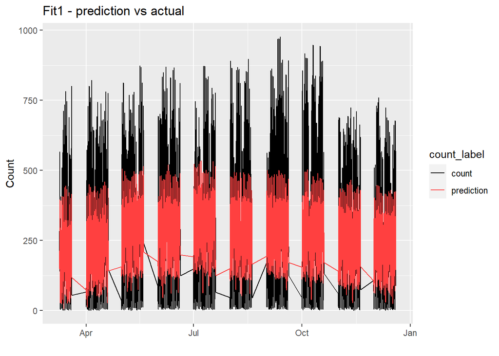

```r
# obtain the predictions for the "data_test" with the model fit1
lm.predict1 <- tibble( predict.lm(fit1, data_test) )

# Plotting the prediction vs actuals
colnames(lm.predict1) <- "prediction"
plot_data <- bind_cols(data_test, lm.predict1) %>%
    pivot_longer(cols = c(prediction, count), names_to = "count_label",
                 values_to = "count_values")

ggplot(plot_data, aes(x = datetime, y = count_values, color = count_label)) +
  geom_line() +
  scale_color_manual(values=c("black", "brown1")) +
  labs(title = "Fit1 - prediction vs actual", x = "", y = "Count")
```

```r
# Calculate MSE for the first model
mse1 <- mean((lm.predict1$prediction - data_test$count)^2, na.rm = TRUE)
cat("MSE for fit1: ", mse1)
```

```
## MSE for fit1:  20172.56
```

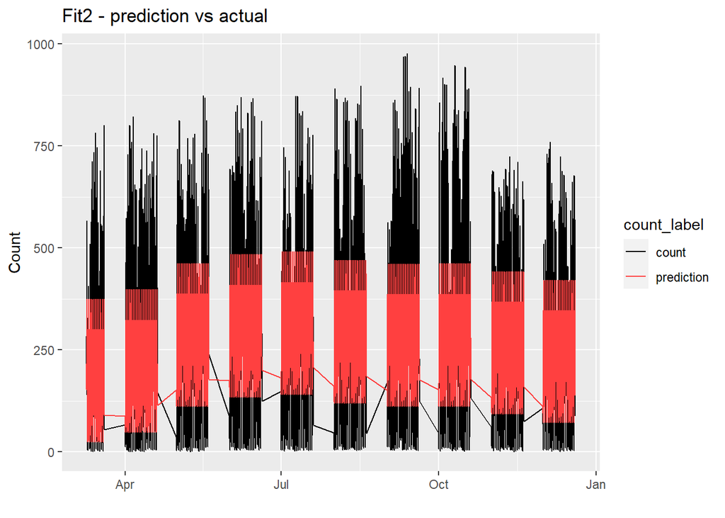

```r
# Obtain the predictions for the "data_test" with the model fit2
lm.predict2 <- tibble( predict.lm(fit2, data_test) )


# Plotting the prediction vs actual
colnames(lm.predict2) <- "prediction"
plot_data <- bind_cols(data_test, lm.predict2) %>%
    pivot_longer(cols = c(prediction, count), names_to = "count_label",
                 values_to = "count_values")

ggplot(plot_data, aes(x = datetime, y = count_values, color = count_label)) +
  geom_line() +
  scale_color_manual(values=c("black", "brown1")) +
  labs(title = "Fit2 - prediction vs actual", x = "", y = "Count")
```

```r
# Calculate MSE for the second model
mse2 <-  mean((lm.predict2$prediction - data_test$count)^2, na.rm = TRUE)
cat("MSE for fit2: ", mse2)
```

```
## MSE for fit2:  21779.55
```

**Model Selection**

Based on the results, which model do we prefer?

**Answer:** Based on the MSE, the preferred model is `fit1`. Its MSE is 1607 units lower than that of `fit2`. From the plot we can see that `fit1` catches more of the peak deviations, while `fit2` has a very constant deviation around the mean.

It is also interesting to have some kind of visual inspection of the predictions of the models. One possibility is to use a scatter plot of the errors.

Using the model you have selected, we obtain a scatter plot of true values of “count” against its predictions for the test set (“data_test”). Additionally, we draw the line that represents the points where the X-coordinate is equal to the Y-coordinate. This way we can inspect how the predictions compare to the true values and if there is some pattern etc. in the error:

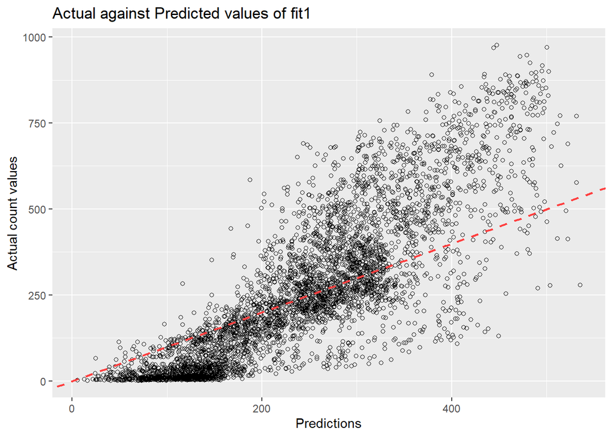

```r
# select the plotting data
plot_data <- bind_cols(data_test, lm.predict1)

# Plot the data
ggplot(plot_data, aes(x = prediction, y = count)) +
  geom_point(shape = 1) +
  geom_abline(intercept = 0, slope = 1, color = "brown1", linetype = 2,
              size = 0.8) +
  labs(title = "Actual against Predicted values of fit1", x = "Predictions",
       y = "Actual count values")
```

**Scatter Plot of Errors**

How would this plot look if we could perfectly predict bike demand?

**Answer:** If all predictions where identical to the true values, the plot would be equal to the plotted line $y=x$.

As the data we analyze is the time series data, it might be also beneficial to plot the predictions and true values against time:

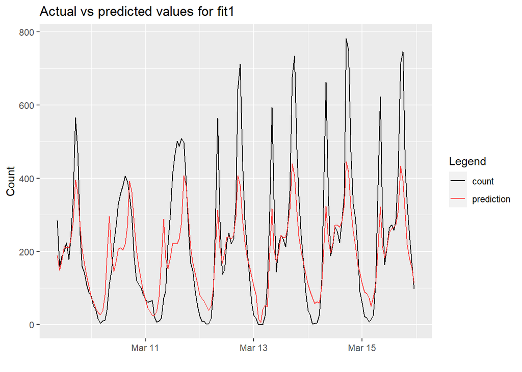

```r
# Selecting the plotting data (first 7 days)
colnames(lm.predict1) <- "prediction"
plot_data <- bind_cols(data_test, lm.predict1) %>%
  filter(datetime < as.Date(datetime)[1] + 7) %>%
  pivot_longer(cols = c(prediction, count), names_to = "count_label",
               values_to = "count_values")

# Plot the data
ggplot(plot_data, aes(x = datetime, y = count_values, color = count_label)) +
  geom_line() +
  scale_color_manual(values=c("black", "brown1")) +
  labs(title = "Actual vs predicted values for fit1", y = "Count", x = "",
       color = "Legend")
```

**Model Performance**

How does the model perform and What are improvement that we could make to enhance predictions?

**Answer:** From the plot, there are two immediate observable failures of the model. First, it fails to model the peaks and troughs, especially during working days. Second, it fails to adjust the model during weekends, where the distribution is uni-modal and not bi-modal. Still, the general shape during working days seems to be caught relatively well by the model. Finally, when looking at the fitted values we can see some negative estimates. This is obviously impossible and the model could be specified to allow only for positive values.

The failure to correctly fit the peaks might be due to insufficient data during the year 2012. We saw that in 2012 rentals were generally higher. We can try to overcome this by splitting the model into 80% train and 20% test data. Nevertheless, this problem seems to be persistent. To overcome the negative fitted values problem, we can try transform `count` into `log(count)`. Fortunately, this transformation also deals with the previous problem of the 2012 predictions. This makes sense, since we know from the distribution analysis that the histogram of `count` is heavily skewed and thus implies that a transformation would support the predictions.

In addition we could try many more transformations and interactions, discretionary or programmatically. However, for the scope of this assignment we stick with `fit4` as our submission model.

```r
# Re-split the sample because there were not enough sample points for 2012
n <- dim(data)[1]
n_train <- as.integer(0.8*n)

data_train <- data[1 : n_train, ]
data_test <- data[ n_train + 1 : n, ]


# Fitting model 3 with hour * weather, hour * workingday and log(count)
fit3 <- lm(data = data_train, formula = log(count) ~ month + holiday + temp
           + humidity + windspeed + year + hour * workingday + hour * weather)
summary(fit3)
```

```
##
## Call:
## lm(formula = log(count) ~ month + holiday + temp + humidity +
##     windspeed + year + hour * workingday + hour * weather, data = data_train)
##
## Residuals:
##      Min       1Q   Median       3Q      Max
## -2.76698 -0.17759  0.02381  0.20885  2.24216
##
## Coefficients: (23 not defined because of singularities)
##                      Estimate Std. Error t value Pr(>|t|)
## (Intercept)         3.3013767  0.0475695  69.401  < 2e-16 ***
## month2              0.1933527  0.0191050  10.121  < 2e-16 ***
## month3              0.2913097  0.0206028  14.139  < 2e-16 ***
## month4              0.5162745  0.0221729  23.284  < 2e-16 ***
## month5              0.7417111  0.0257434  28.812  < 2e-16 ***
## month6              0.7002960  0.0297658  23.527  < 2e-16 ***
## month7              0.5919509  0.0336692  17.581  < 2e-16 ***
## month8              0.6615269  0.0350995  18.847  < 2e-16 ***
## month9              0.7498435  0.0322547  23.248  < 2e-16 ***
## month10             0.8771097  0.0286965  30.565  < 2e-16 ***
## month11             0.8346041  0.0253622  32.907  < 2e-16 ***
## month12             0.7629132  0.0242879  31.411  < 2e-16 ***
## holiday1           -0.0300805  0.0273289  -1.101 0.271065
## temp                0.0270495  0.0013163  20.549  < 2e-16 ***
## humidity           -0.0016819  0.0003035  -5.542 3.07e-08 ***
## windspeed          -0.0047651  0.0005614  -8.488  < 2e-16 ***
## year2012            0.5416954  0.0099689  54.339  < 2e-16 ***
## hour1              -0.2883072  0.0564015  -5.112 3.26e-07 ***
## hour2              -0.5746325  0.0563880 -10.191  < 2e-16 ***
## hour3              -1.2993462  0.0563269 -23.068  < 2e-16 ***
## hour4              -2.4581367  0.0559695 -43.919  < 2e-16 ***
## hour5              -2.4615486  0.0559922 -43.962  < 2e-16 ***
## hour6              -1.7699005  0.0558035 -31.717  < 2e-16 ***
## hour7              -0.8235384  0.0555392 -14.828  < 2e-16 ***
## hour8               0.0668606  0.0553044   1.209 0.226713
## hour9               0.5733622  0.0552937  10.369  < 2e-16 ***
## hour10              0.9630565  0.0553635  17.395  < 2e-16 ***
## hour11              1.1564312  0.0552458  20.932  < 2e-16 ***
## hour12              1.3001029  0.0557029  23.340  < 2e-16 ***
```

[output cut: 98 more lines]

```
## hour15:weather4            NA         NA      NA       NA
## hour16:weather4            NA         NA      NA       NA
## hour17:weather4            NA         NA      NA       NA
## hour18:weather4            NA         NA      NA       NA
## hour19:weather4            NA         NA      NA       NA
## hour20:weather4            NA         NA      NA       NA
## hour21:weather4            NA         NA      NA       NA
## hour22:weather4            NA         NA      NA       NA
## hour23:weather4            NA         NA      NA       NA
## ---
## Signif. codes:  0 '***' 0.001 '**' 0.01 '*' 0.05 '.' 0.1 ' ' 1
##
## Residual standard error: 0.3961 on 8595 degrees of freedom
## Multiple R-squared:  0.9306, Adjusted R-squared:  0.9297
## F-statistic:  1029 on 112 and 8595 DF,  p-value: < 2.2e-16
```

```r
# Calculate the predictions
lm.predict3 <- tibble( predict.lm(fit3, data_test) )
colnames(lm.predict3) <- "prediction"

# Calculate MSE, for comparison transform back to count level
mse3 <- mean( (exp(lm.predict3$prediction) - data_test$count)^2, na.rm = TRUE)
cat("\nMSE for fit3: ", mse3)
```

```
##
## MSE for fit3:  5462.091
```

Because the interaction creates some errors, we re-estimate the model without the interaction between `hour` and `weather`.

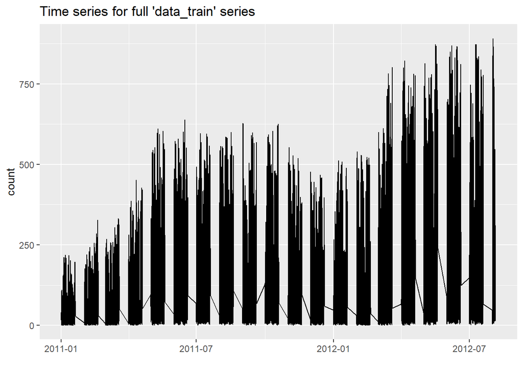

```r
# Plotting the whole series for reference
ggplot(data_train, aes(x = datetime, y = count)) +
  geom_line() +
  labs(title = "Time series for full 'data_train' series", y = "count", x = "")
```

```r
# Re-split the sample because there were not enough sample points for 2012
n <- dim(data)[1]
n_train <- as.integer(0.8*n)

data_train <- data[1 : n_train, ]
data_test <- data[ n_train + 1 : n, ]


# Fitting model 4 with hours * workingday and log(count)
fit4 <- lm(data = data_train, formula = log(count) ~ month + holiday + weather
           + temp + humidity + windspeed + year + hour * workingday)
summary(fit4)
```

```
##
## Call:
## lm(formula = log(count) ~ month + holiday + weather + temp +
##     humidity + windspeed + year + hour * workingday, data = data_train)
##
## Residuals:
##      Min       1Q   Median       3Q      Max
## -2.74928 -0.17621  0.02827  0.21027  2.21159
##
## Coefficients:
##                      Estimate Std. Error t value Pr(>|t|)
## (Intercept)         3.2781288  0.0459010  71.417  < 2e-16 ***
## month2              0.1921284  0.0191728  10.021  < 2e-16 ***
## month3              0.2891418  0.0205920  14.041  < 2e-16 ***
## month4              0.5093601  0.0221276  23.019  < 2e-16 ***
## month5              0.7362609  0.0256758  28.675  < 2e-16 ***
## month6              0.6896734  0.0295316  23.354  < 2e-16 ***
## month7              0.5798475  0.0333917  17.365  < 2e-16 ***
## month8              0.6497055  0.0348309  18.653  < 2e-16 ***
## month9              0.7415376  0.0321135  23.091  < 2e-16 ***
## month10             0.8654439  0.0286346  30.224  < 2e-16 ***
## month11             0.8259528  0.0254108  32.504  < 2e-16 ***
## month12             0.7580314  0.0243517  31.129  < 2e-16 ***
## holiday1           -0.0316096  0.0274028  -1.154 0.248730
## weather2           -0.0809324  0.0108102  -7.487 7.76e-14 ***
## weather3           -0.6138352  0.0176894 -34.701  < 2e-16 ***
## weather4           -0.3812651  0.3994396  -0.955 0.339857
## temp                0.0275990  0.0012974  21.272  < 2e-16 ***
## humidity           -0.0018384  0.0003018  -6.091 1.17e-09 ***
## windspeed          -0.0046412  0.0005626  -8.249  < 2e-16 ***
## year2012            0.5399939  0.0100018  53.990  < 2e-16 ***
## hour1              -0.2499464  0.0522848  -4.780 1.78e-06 ***
## hour2              -0.5155077  0.0525169  -9.816  < 2e-16 ***
## hour3              -1.2674562  0.0524165 -24.180  < 2e-16 ***
## hour4              -2.4030084  0.0523197 -45.929  < 2e-16 ***
## hour5              -2.4255564  0.0528069 -45.933  < 2e-16 ***
## hour6              -1.7447653  0.0524746 -33.250  < 2e-16 ***
## hour7              -0.8174032  0.0524465 -15.585  < 2e-16 ***
## hour8               0.0969458  0.0524116   1.850 0.064391 .
## hour9               0.6046013  0.0523993  11.538  < 2e-16 ***
```

[output cut: 29 more lines]

```
## hour15:workingday1  0.3191972  0.0633765   5.037 4.84e-07 ***
## hour16:workingday1  0.7230543  0.0633787  11.408  < 2e-16 ***
## hour17:workingday1  1.4524801  0.0633762  22.918  < 2e-16 ***
## hour18:workingday1  1.5738431  0.0633968  24.825  < 2e-16 ***
## hour19:workingday1  1.3848294  0.0633741  21.852  < 2e-16 ***
## hour20:workingday1  1.2975213  0.0633765  20.473  < 2e-16 ***
## hour21:workingday1  1.2422747  0.0633749  19.602  < 2e-16 ***
## hour22:workingday1  1.1414262  0.0633781  18.010  < 2e-16 ***
## hour23:workingday1  0.9825454  0.0633796  15.503  < 2e-16 ***
## ---
## Signif. codes:  0 '***' 0.001 '**' 0.01 '*' 0.05 '.' 0.1 ' ' 1
##
## Residual standard error: 0.3981 on 8641 degrees of freedom
## Multiple R-squared:  0.9295, Adjusted R-squared:  0.929
## F-statistic:  1727 on 66 and 8641 DF,  p-value: < 2.2e-16
```